# Open research in life science: funding foundational tools, trust, and talent

Yo Yehudi, Open Source Tech Lead, Data for Science and Health, Wellcome Trust

January 8, 2021

# Meet Sam

Sam does science in a lab, and is what many people might think of as a “traditional” scientist.

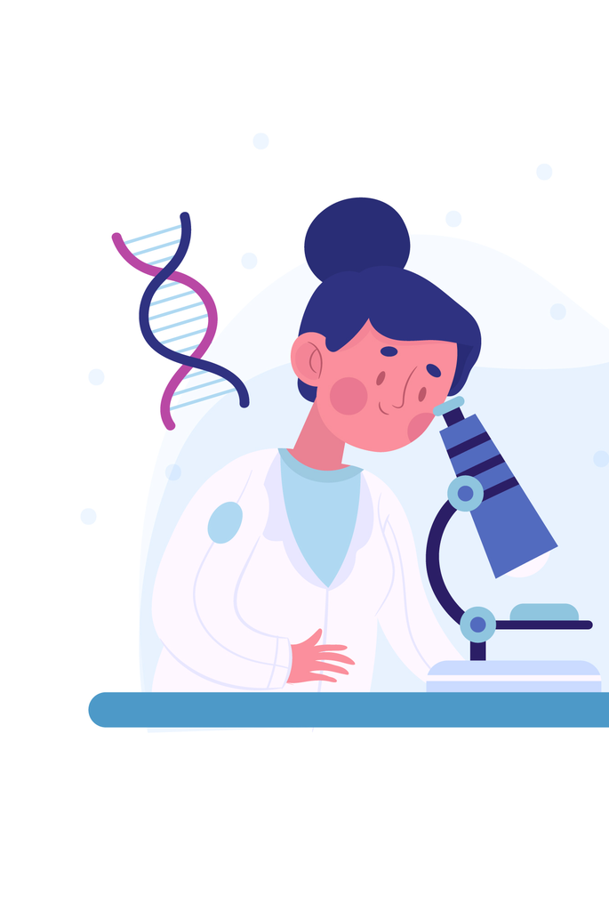

# Now meet Joy

Joy works in the same area as Sam, but writes computer code to do their work, a **non-traditional academic output**.

[figure not shown]

[People vector created by pikisuperstar - www.freepik.com](https://www.freepik.com/vectors/people)

# It’s all ESSENTIAL

Say and Joy both do essential research work, but we’ll be focusing on Joy, and some of the challenges they face:

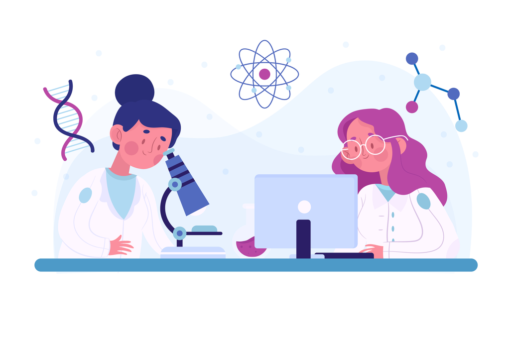

# Challenges for computational research

Missing computational **tools** for research, insufficient incentive to draw, retain, and reward **talent**, and insufficient **trust** in computational work.

# Tools

- Much research is so niche the computational tools needed may not exist, *and yet…*
- Sometimes it’s the opposite, and tools are fragmented across many software tools and standards.

[figure not shown]

# Trust

A lot of tech has a **bad name** for a **good reason** - companies, governments, healthcare officials, and researchers don’t always use people’s data in trustworthy ways.

# Talent

- Code is not papers
- Good practice may not be directly appreciated (except by future you and other maintainers)

# Talent

- May not be shared, or may not be open in spirit
- Researchers may (justifiably) feel the need to hide the code aspects of their work in a grant application, or not realise they are doing (or should be doing) software engineering / data science

# Talent

# Data for Science and Health

Our goal: To fund the Tools, Talent, Trust and make trustworthy data science a first-class citizen in the research ecosystem

# What Wellcome focuses on

The Wellcome Trust’s strategy focuses on three primary areas, as well as a broader “discovery research” umbrella:

- Global heating
- Mental health
- Infectious disease

# Open work we’ve (co-)funded so far

**AfriMapr**

Open source shiny-based tool that integrates healthcare facility locations and shows on a map. github.com/afrimapr

[figure not shown]

# Open work we’ve (co-)funded so far

**OpenSAFELY**

Open tool to make computational work across healthcare data secure and safe. [github.com/opensafely](https://github.com/opensafely/)

# Shining a spotlight on the **good**

Well-done software means focusing on maintainable code, but also on:

- Documentation (for users *and* developers)
- Accessibility (in the sense of [a11y](https://www.a11yproject.com/), rather than [FAIR](https://www.go-fair.org/fair-principles/))
- Healthy and diverse community
- UX (User Experience)

# Interested / think there might be a good fit?

Currently looking for:  
- Software to share - Guest editors to help curate collections

# Interested / think there might be a good fit?

If you have a project idea that you think might fit into our funding interests, [please contact us](https://wellcome.org/what-we-do/our-work/data-science-and-health-trustworthy-data-science)!

My email: y.yehudi@wellcome.org

The team: ContactDataForScienceAndHealth@wellcome.org

Twitter: yoyehudi